# 데이터과학과 소셜데이터분석_김장현 교수님

# 과제2_2019313240_전효림

# 1. 데이터 준비

```python
# 패키지 불러오기
import numpy as np
from pandas import Series, DataFrame
import pandas as pd
import matplotlib.pyplot as plt
import seaborn as sns
import os
import math
```

```python
# 데이터 불러오기
data = pd.read_csv("C:/Users/hyolim/[데이터과학과 소셜데이터분석]/data.csv")
data
```

|  | index | gender | car | reality | child_num | income_total | income_type | edu_type | family_type | house_type | DAYS_BIRTH | DAYS_EMPLOYED | FLAG_MOBIL | work_phone | phone | email | occyp_type | family_size | begin_month | credit |
| --- | --- | --- | --- | --- | --- | --- | --- | --- | --- | --- | --- | --- | --- | --- | --- | --- | --- | --- | --- | --- |
| 0 | 0 | F | N | N | 0 | 202500.0 | Commercial associate | Higher education | Married | Municipal apartment | -13899 | -4709 | 1 | 0 | 0 | 0 | NaN | 2.0 | -6.0 | 1.0 |
| 1 | 1 | F | N | Y | 1 | 247500.0 | Commercial associate | Secondary / secondary special | Civil marriage | House / apartment | -11380 | -1540 | 1 | 0 | 0 | 1 | Laborers | 3.0 | -5.0 | 1.0 |
| 2 | 2 | M | Y | Y | 0 | 450000.0 | Working | Higher education | Married | House / apartment | -19087 | -4434 | 1 | 0 | 1 | 0 | Managers | 2.0 | -22.0 | 2.0 |
| 3 | 3 | F | N | Y | 0 | 202500.0 | Commercial associate | Secondary / secondary special | Married | House / apartment | -15088 | -2092 | 1 | 0 | 1 | 0 | Sales staff | 2.0 | -37.0 | 0.0 |
| 4 | 4 | F | Y | Y | 0 | 157500.0 | State servant | Higher education | Married | House / apartment | -15037 | -2105 | 1 | 0 | 0 | 0 | Managers | 2.0 | -26.0 | 2.0 |
| ... | ... | ... | ... | ... | ... | ... | ... | ... | ... | ... | ... | ... | ... | ... | ... | ... | ... | ... | ... | ... |
| 26452 | 26452 | F | N | N | 2 | 225000.0 | State servant | Secondary / secondary special | Married | House / apartment | -12079 | -1984 | 1 | 0 | 0 | 0 | Core staff | 4.0 | -2.0 | 1.0 |
| 26453 | 26453 | F | N | Y | 1 | 180000.0 | Working | Higher education | Separated | House / apartment | -15291 | -2475 | 1 | 0 | 0 | 0 | NaN | 2.0 | -47.0 | 2.0 |
| 26454 | 26454 | F | Y | N | 0 | 292500.0 | Working | Secondary / secondary special | Civil marriage | With parents | -10082 | -2015 | 1 | 0 | 0 | 0 | Core staff | 2.0 | -25.0 | 2.0 |
| 26455 | 26455 | M | N | Y | 0 | 171000.0 | Working | Incomplete higher | Single / not married | House / apartment | -10145 | -107 | 1 | 0 | 0 | 0 | Laborers | 1.0 | -59.0 | 2.0 |
| 26456 | 26456 | F | N | N | 0 | 81000.0 | Working | Secondary / secondary special | Civil marriage | House / apartment | -19569 | -1013 | 1 | 0 | 0 | 0 | Security staff | 2.0 | -9.0 | 2.0 |

26457 rows × 20 columns

## 데이터 열

##### 각 열이 의미하는 바를 정리.

index

gender: 성별

car: 차량 소유 여부

reality: 부동산 소유 여부

child_num: 자녀 수

income_total: 연간 소득

income_type: 소득 분류 ['Commercial associate', 'Working', 'State servant', 'Pensioner', 'Student']

edu_type: 교육 수준 ['Higher education' ,'Secondary / secondary special', 'Incomplete higher', 'Lower secondary', 'Academic degree']

family_type: 결혼 여부 ['Married', 'Civil marriage', 'Separated', 'Single / not married', 'Widow']

house_type: 생활 방식 ['Municipal apartment', 'House / apartment', 'With parents', 'Co-op apartment', 'Rented apartment', 'Office apartment']

DAYS*BIRTH: 출생일* 데이터 수집 당시 (0)부터 역으로 셈, 즉, -1은 데이터 수집일 하루 전에 태어났음을 의미

DAYS*EMPLOYED: 업무 시작일* 데이터 수집 당시 (0)부터 역으로 셈, 즉, -1은 데이터 수집일 하루 전부터 일을 시작함을 의미, 양수 값은 고용되지 않은 상태를 의미함

FLAG_MOBIL: 핸드폰 소유 여부

work_phone: 업무용 전화 소유 여부

phone: 전화 소유 여부

email: 이메일 소유 여부

occyp_type: 직업 유형

family_size: 가족 규모

begin_month: 신용카드 발급 월 데이터 수집 당시 (0)부터 역으로 셈, 즉, -1은 데이터 수집일 한 달 전에 신용카드를 발급함을 의미

credit: 사용자의 신용카드 대금 연체를 기준으로 한 신용도, 낮을 수록 높은 신용의 신용카드 사용자를 의미함

```python
# Data 구조, null값 개수, Data Type 확인
data.info()

# Data구조: 26457 rows × 20 columns
# null값 개수: 16번째 열, occyp_type를 제외하고 빈 값 존재하지 않음.
# Data Type: float64(4), int64(8), object(8)으로 총 3가지.
```

```
<class 'pandas.core.frame.DataFrame'>
RangeIndex: 26457 entries, 0 to 26456
Data columns (total 20 columns):
 #   Column         Non-Null Count  Dtype
---  ------         --------------  -----
 0   index          26457 non-null  int64
 1   gender         26457 non-null  object
 2   car            26457 non-null  object
 3   reality        26457 non-null  object
 4   child_num      26457 non-null  int64
 5   income_total   26457 non-null  float64
 6   income_type    26457 non-null  object
 7   edu_type       26457 non-null  object
 8   family_type    26457 non-null  object
 9   house_type     26457 non-null  object
 10  DAYS_BIRTH     26457 non-null  int64
 11  DAYS_EMPLOYED  26457 non-null  int64
 12  FLAG_MOBIL     26457 non-null  int64
 13  work_phone     26457 non-null  int64
 14  phone          26457 non-null  int64
 15  email          26457 non-null  int64
 16  occyp_type     18286 non-null  object
 17  family_size    26457 non-null  float64
 18  begin_month    26457 non-null  float64
 19  credit         26457 non-null  float64
dtypes: float64(4), int64(8), object(8)
memory usage: 4.0+ MB
```

```python
# data type 변환.
data['income_total'] = data['income_total'].astype(np.int64)
data['begin_month'] = data['begin_month'].astype(np.int64)
data['family_size'] = data['family_size'].astype(np.int64)
data['credit'] = data['credit'].astype(np.int64)

# Dtype이 float64인 4열을 int64로 변환 후 결과 확인.

data.info()

# 확인 결과, dtypes가 2 종류로 줄어듦.
```

```
<class 'pandas.core.frame.DataFrame'>
RangeIndex: 26457 entries, 0 to 26456
Data columns (total 20 columns):
 #   Column         Non-Null Count  Dtype
---  ------         --------------  -----
 0   index          26457 non-null  int64
 1   gender         26457 non-null  object
 2   car            26457 non-null  object
 3   reality        26457 non-null  object
 4   child_num      26457 non-null  int64
 5   income_total   26457 non-null  int64
 6   income_type    26457 non-null  object
 7   edu_type       26457 non-null  object
 8   family_type    26457 non-null  object
 9   house_type     26457 non-null  object
 10  DAYS_BIRTH     26457 non-null  int64
 11  DAYS_EMPLOYED  26457 non-null  int64
 12  FLAG_MOBIL     26457 non-null  int64
 13  work_phone     26457 non-null  int64
 14  phone          26457 non-null  int64
 15  email          26457 non-null  int64
 16  occyp_type     18286 non-null  object
 17  family_size    26457 non-null  int64
 18  begin_month    26457 non-null  int64
 19  credit         26457 non-null  int64
dtypes: int64(12), object(8)
memory usage: 4.0+ MB
```

# 2. 데이터 시각화

```python
data.columns
# 시각화를 할 열들을 확인해봄.
```

```
Index(['index', 'gender', 'car', 'reality', 'child_num', 'income_total',
       'income_type', 'edu_type', 'family_type', 'house_type', 'DAYS_BIRTH',
       'DAYS_EMPLOYED', 'FLAG_MOBIL', 'work_phone', 'phone', 'email',
       'occyp_type', 'family_size', 'begin_month', 'credit'],
      dtype='object')
```

## 1) 시각화 대상 열 선정

### (1) 시각화 생략 열

( 특별한 설명이 없는 경우, credit열과의 결과 관계가 무의미할 것으로 판단되어 시각화를 생략함)

child_num: 자녀 수(=> family_size(가족규모)로 합쳐서 한 번에 확인 가능)

income_total: 연간 소득(=> 수치가 너무 다양하여 시각화에서는 생략)

income_type: 소득 분류

edu_type: 교육 수준

family_type: 결혼 여부(=> family_size(가족규모)로 합쳐서 한 번에 확인 가능)

house_type: 생활 방식

DAYS_BIRTH: 출생일(=> 음수 값 형태이며 일자를 기준으로 값이 나와있어 추후 연 단위로 변경)

DAYS_EMPLOYED: 업무 시작일 (=> 음수 값 형태이며 일자를 기준으로 값이 나와있어 추후 연 단위로 변경)

FLAG_MOBIL: 핸드폰 소유 여부(=> 모두 핸드폰 소유, 시각화 결과 무의미로 생략)

work_phone: 업무용 전화 소유 여부

phone: 전화 소유 여부

email: 이메일 소유 여부

occyp_type: 직업 유형(1. 종류별로 도수가 너무 다양함,

```
                  2. null 값 존재, 그러나 결측치 처리 불가(결측치 처리 과정에서 추후 자세히 다룰 예정. 시각화 생략))
```

begin_month: 신용카드 발급 월 (=> 음수 값 형태, 추후 양수로 변경.)

### (2) 시각화 대상 열

gender: 성별 # 시각화2

car: 차량 소유 # 시각화3

reality: 부동산 소유 # 시각화4

=> 세 열은 시각화 후, 명목변수 인코딩 진행 여부 결정

family_size: 가족 규모 # 시각화5

credit: 신용도 # 시각화1

```python
# 종류별로 도수 확인.
data['FLAG_MOBIL'].value_counts()

# 모두 핸드폰 소유, 시각화 무의미.
```

```
1    26457
Name: FLAG_MOBIL, dtype: int64
```

```python
# 종류별로 도수 확인.
data['occyp_type'].value_counts()

# 직업 종류가 너무 다양함,income_total 또한 유사한 이유로 시각화 생략.
```

```
Laborers                 4512
Core staff               2646
Sales staff              2539
Managers                 2167
Drivers                  1575
High skill tech staff    1040
Accountants               902
Medicine staff            864
Cooking staff             457
Security staff            424
Cleaning staff            403
Private service staff     243
Low-skill Laborers        127
Waiters/barmen staff      124
Secretaries                97
Realty agents              63
HR staff                   62
IT staff                   41
Name: occyp_type, dtype: int64
```

## 2) 시각화

```python
# 종류별로 도수 확인.
data['credit'].value_counts()

# 신용도를 확인해본 결과, 2, 1, 0으로 총 세 종류.
```

```
2    16968
1     6267
0     3222
Name: credit, dtype: int64
```

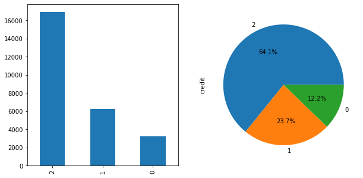

```python
# 시각화1
# 신용도 분포 확인
plt.figure(figsize=(10,5))
plt.subplot(1,2,1)

# 신용 분포에 대한 막대그래프
data['credit'].value_counts().plot(kind='bar')

plt.subplot(1,2,2)

# 신용 분포에 대한 파이그래프
data["credit"].value_counts().plot(kind = "pie", autopct='%1.1f%%')
```

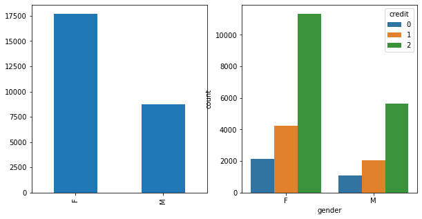

```python
# 시각화2
plt.figure(figsize=(10,5))
plt.subplot(1,2,1)

# 성별 분포에 대한 막대그래프
data["gender"].value_counts().plot(kind = "bar")

plt.subplot(1,2,2)

# 성별에 따른 신용도 분포
sns.countplot(data=data, x="gender", hue="credit")

# 시각화 결과, 신용도와 관계가 유의미할 것으로 보임.
```

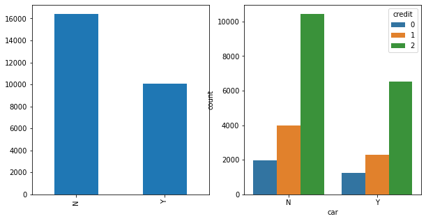

```python
# 시각화3
plt.figure(figsize=(10,5))
plt.subplot(1,2,1)

# 차량 소유 분포에 대한 막대그래프
data["car"].value_counts().plot(kind = "bar")

plt.subplot(1,2,2)

# 차량 소유에 따른 신용도 분포
sns.countplot(data=data, x="car", hue="credit")

# 시각화 결과, 신용도와 관계가 유의미할 것으로 보임.
```

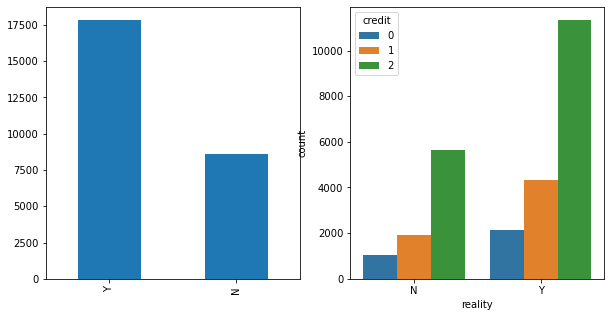

```python
# 시각화4
plt.figure(figsize=(10,5))
plt.subplot(1,2,1)

# 부동산 소유 분포에 대한 막대그래프
data["reality"].value_counts().plot(kind = "bar")

plt.subplot(1,2,2)

# 부동산 소유에 따른 신용도 분포
sns.countplot(data=data, x="reality", hue="credit")

# 시각화 결과, 신용도와 관계가 유의미할 것으로 보임.
```

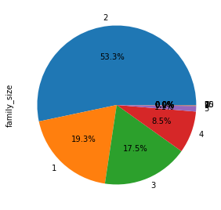

```python
# 시각화5
plt.figure(figsize=(10,5))
plt.subplot(1,2,1)

# 가족 규모 분포에 대한 파이그래프
data["family_size"].value_counts().plot(kind = "pie", autopct='%1.1f%%')
```

```python
# 종류별로 도수 확인.
data['family_size'].value_counts()

# 수가 9 이상인 경우, 이상치로 판단.
```

```
2     14106
1      5109
3      4632
4      2260
5       291
6        44
7         9
15        3
9         2
20        1
Name: family_size, dtype: int64
```

```python
# 이상치 처리
delete_row = data[data['family_size']>=9].index
data=data.drop(delete_row)

data['family_size'].value_counts()

# 9 이상의 값에 해당하는 6개의 행이 삭제됨.
```

```
2    14106
1     5109
3     4632
4     2260
5      291
6       44
7        9
Name: family_size, dtype: int64
```

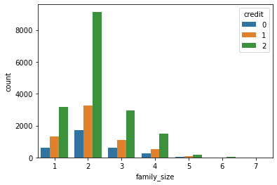

```python
# 가족 규모에 따른 신용도 분포
sns.countplot(data=data, x="family_size", hue="credit")

# 시각화 결과, 신용도와 관계가 유의미할 것으로 보임.
```

# 3. 데이터 정리

## 1) 결측값 정리

```python
data.isnull()
```

|  | index | gender | car | reality | child_num | income_total | income_type | edu_type | family_type | house_type | DAYS_BIRTH | DAYS_EMPLOYED | FLAG_MOBIL | work_phone | phone | email | occyp_type | family_size | begin_month | credit |
| --- | --- | --- | --- | --- | --- | --- | --- | --- | --- | --- | --- | --- | --- | --- | --- | --- | --- | --- | --- | --- |
| 0 | False | False | False | False | False | False | False | False | False | False | False | False | False | False | False | False | True | False | False | False |
| 1 | False | False | False | False | False | False | False | False | False | False | False | False | False | False | False | False | False | False | False | False |
| 2 | False | False | False | False | False | False | False | False | False | False | False | False | False | False | False | False | False | False | False | False |
| 3 | False | False | False | False | False | False | False | False | False | False | False | False | False | False | False | False | False | False | False | False |
| 4 | False | False | False | False | False | False | False | False | False | False | False | False | False | False | False | False | False | False | False | False |
| ... | ... | ... | ... | ... | ... | ... | ... | ... | ... | ... | ... | ... | ... | ... | ... | ... | ... | ... | ... | ... |
| 26452 | False | False | False | False | False | False | False | False | False | False | False | False | False | False | False | False | False | False | False | False |
| 26453 | False | False | False | False | False | False | False | False | False | False | False | False | False | False | False | False | True | False | False | False |
| 26454 | False | False | False | False | False | False | False | False | False | False | False | False | False | False | False | False | False | False | False | False |
| 26455 | False | False | False | False | False | False | False | False | False | False | False | False | False | False | False | False | False | False | False | False |
| 26456 | False | False | False | False | False | False | False | False | False | False | False | False | False | False | False | False | False | False | False | False |

26451 rows × 20 columns

```python
data.isnull().sum() # True(숫자 1), False(숫자 0)이므로 합계(sum)는 null data의 개수를 나타냄.

# 결측치 존재 열: occyp_type, 8171행
```

```
index               0
gender              0
car                 0
reality             0
child_num           0
income_total        0
income_type         0
edu_type            0
family_type         0
house_type          0
DAYS_BIRTH          0
DAYS_EMPLOYED       0
FLAG_MOBIL          0
work_phone          0
phone               0
email               0
occyp_type       8171
family_size         0
begin_month         0
credit              0
dtype: int64
```

```python
data.occyp_type
# 확인 결과, 직업 유형을 예측하는 것에는 어려움이 있어 보임.
# 따라서 다음 단계에서 해당 열을 삭제.
```

```
0                   NaN
1              Laborers
2              Managers
3           Sales staff
4              Managers
              ...
26452        Core staff
26453               NaN
26454        Core staff
26455          Laborers
26456    Security staff
Name: occyp_type, Length: 26451, dtype: object
```

## 2) Feature Selection - 변수 선택 및 제외

```python
# 예측에 유용하지 않다고 생각된다면 제외

drop_cols = ['index','child_num','income_type','FLAG_MOBIL','house_type','edu_type',
             'family_type','occyp_type', 'work_phone', 'phone', 'email']
data1 = data.drop(drop_cols, axis=1)
data1

# 9개의 열이 남음. 크게 세 카테고리로 나누어서 추후 진행 예정.
# DAYS_BIRTH, DAYS_EMPLOYED, begin_month 열의 경우 값 변환.
# gender, car, reality 열의 경우 명목변수 인코딩.
# income_total, family_size, credit 열은 그대로 사용 예정.
```

|  | gender | car | reality | income_total | DAYS_BIRTH | DAYS_EMPLOYED | family_size | begin_month | credit |
| --- | --- | --- | --- | --- | --- | --- | --- | --- | --- |
| 0 | F | N | N | 202500 | -13899 | -4709 | 2 | -6 | 1 |
| 1 | F | N | Y | 247500 | -11380 | -1540 | 3 | -5 | 1 |
| 2 | M | Y | Y | 450000 | -19087 | -4434 | 2 | -22 | 2 |
| 3 | F | N | Y | 202500 | -15088 | -2092 | 2 | -37 | 0 |
| 4 | F | Y | Y | 157500 | -15037 | -2105 | 2 | -26 | 2 |
| ... | ... | ... | ... | ... | ... | ... | ... | ... | ... |
| 26452 | F | N | N | 225000 | -12079 | -1984 | 4 | -2 | 1 |
| 26453 | F | N | Y | 180000 | -15291 | -2475 | 2 | -47 | 2 |
| 26454 | F | Y | N | 292500 | -10082 | -2015 | 2 | -25 | 2 |
| 26455 | M | N | Y | 171000 | -10145 | -107 | 1 | -59 | 2 |
| 26456 | F | N | N | 81000 | -19569 | -1013 | 2 | -9 | 2 |

26451 rows × 9 columns

## 3) 변수 변환

```python
# 변환1
# 새로운 파생변수가 필요하지는 않아, DAYS_BIRTH, DAYS_EMPLOYED, begin_month 열의 경우 값 변환.

# DAYS_BIRTH => 양수로 변환. 일자를 연 단위로 변환, age로 열 이름 바꿈.
# DAYS_EMPLOYED => 양수로 변환. 일자를 연 단위로 변환, years_work로 열 이름 바꿈.
# begin_month => 양수로 변환. 열 이름은 그대로
data1['age']=round(abs(data1['DAYS_BIRTH'])/365)
data1['years_work']=round(abs(data1['DAYS_EMPLOYED'])/365)
data1['begin_month']=abs(data1['begin_month'])
data1

# 9개의 열이었던 데이터셋이 2개의 열이 새로 추가되어 11개의 열로 바뀜.
```

|  | gender | car | reality | income_total | DAYS_BIRTH | DAYS_EMPLOYED | family_size | begin_month | credit | age | years_work |
| --- | --- | --- | --- | --- | --- | --- | --- | --- | --- | --- | --- |
| 0 | F | N | N | 202500 | -13899 | -4709 | 2 | 6 | 1 | 38.0 | 13.0 |
| 1 | F | N | Y | 247500 | -11380 | -1540 | 3 | 5 | 1 | 31.0 | 4.0 |
| 2 | M | Y | Y | 450000 | -19087 | -4434 | 2 | 22 | 2 | 52.0 | 12.0 |
| 3 | F | N | Y | 202500 | -15088 | -2092 | 2 | 37 | 0 | 41.0 | 6.0 |
| 4 | F | Y | Y | 157500 | -15037 | -2105 | 2 | 26 | 2 | 41.0 | 6.0 |
| ... | ... | ... | ... | ... | ... | ... | ... | ... | ... | ... | ... |
| 26452 | F | N | N | 225000 | -12079 | -1984 | 4 | 2 | 1 | 33.0 | 5.0 |
| 26453 | F | N | Y | 180000 | -15291 | -2475 | 2 | 47 | 2 | 42.0 | 7.0 |
| 26454 | F | Y | N | 292500 | -10082 | -2015 | 2 | 25 | 2 | 28.0 | 6.0 |
| 26455 | M | N | Y | 171000 | -10145 | -107 | 1 | 59 | 2 | 28.0 | 0.0 |
| 26456 | F | N | N | 81000 | -19569 | -1013 | 2 | 9 | 2 | 54.0 | 3.0 |

26451 rows × 11 columns

```python
# DAYS_BIRTH, DAYS_EMPLOYED 열 삭제하기.
drop_cols = ['DAYS_BIRTH','DAYS_EMPLOYED']
data2 = data1.drop(drop_cols, axis=1)
data2
```

|  | gender | car | reality | income_total | family_size | begin_month | credit | age | years_work |
| --- | --- | --- | --- | --- | --- | --- | --- | --- | --- |
| 0 | F | N | N | 202500 | 2 | 6 | 1 | 38.0 | 13.0 |
| 1 | F | N | Y | 247500 | 3 | 5 | 1 | 31.0 | 4.0 |
| 2 | M | Y | Y | 450000 | 2 | 22 | 2 | 52.0 | 12.0 |
| 3 | F | N | Y | 202500 | 2 | 37 | 0 | 41.0 | 6.0 |
| 4 | F | Y | Y | 157500 | 2 | 26 | 2 | 41.0 | 6.0 |
| ... | ... | ... | ... | ... | ... | ... | ... | ... | ... |
| 26452 | F | N | N | 225000 | 4 | 2 | 1 | 33.0 | 5.0 |
| 26453 | F | N | Y | 180000 | 2 | 47 | 2 | 42.0 | 7.0 |
| 26454 | F | Y | N | 292500 | 2 | 25 | 2 | 28.0 | 6.0 |
| 26455 | M | N | Y | 171000 | 1 | 59 | 2 | 28.0 | 0.0 |
| 26456 | F | N | N | 81000 | 2 | 9 | 2 | 54.0 | 3.0 |

26451 rows × 9 columns

```python
data2.info()
# 데이터 형태 확인.
```

```
<class 'pandas.core.frame.DataFrame'>
Int64Index: 26451 entries, 0 to 26456
Data columns (total 9 columns):
 #   Column        Non-Null Count  Dtype
---  ------        --------------  -----
 0   gender        26451 non-null  object
 1   car           26451 non-null  object
 2   reality       26451 non-null  object
 3   income_total  26451 non-null  int64
 4   family_size   26451 non-null  int64
 5   begin_month   26451 non-null  int64
 6   credit        26451 non-null  int64
 7   age           26451 non-null  float64
 8   years_work    26451 non-null  float64
dtypes: float64(2), int64(4), object(3)
memory usage: 3.3+ MB
```

```python
# 변환2. Feature Engineering - 명목변수 인코딩(One hot Encoding)

# gender, car, reality 열의 경우 원핫인코딩 실시
x1 = pd.get_dummies(data2['gender'])
x2 = pd.get_dummies(data2['car'])
x3 = pd.get_dummies(data2['reality'])
data3 = pd.concat([data2, x1, x2, x3], axis=1)
data3
```

|  | gender | car | reality | income_total | family_size | begin_month | credit | age | years_work | F | M | N | Y | N | Y |
| --- | --- | --- | --- | --- | --- | --- | --- | --- | --- | --- | --- | --- | --- | --- | --- |
| 0 | F | N | N | 202500 | 2 | 6 | 1 | 38.0 | 13.0 | 1 | 0 | 1 | 0 | 1 | 0 |
| 1 | F | N | Y | 247500 | 3 | 5 | 1 | 31.0 | 4.0 | 1 | 0 | 1 | 0 | 0 | 1 |
| 2 | M | Y | Y | 450000 | 2 | 22 | 2 | 52.0 | 12.0 | 0 | 1 | 0 | 1 | 0 | 1 |
| 3 | F | N | Y | 202500 | 2 | 37 | 0 | 41.0 | 6.0 | 1 | 0 | 1 | 0 | 0 | 1 |
| 4 | F | Y | Y | 157500 | 2 | 26 | 2 | 41.0 | 6.0 | 1 | 0 | 0 | 1 | 0 | 1 |
| ... | ... | ... | ... | ... | ... | ... | ... | ... | ... | ... | ... | ... | ... | ... | ... |
| 26452 | F | N | N | 225000 | 4 | 2 | 1 | 33.0 | 5.0 | 1 | 0 | 1 | 0 | 1 | 0 |
| 26453 | F | N | Y | 180000 | 2 | 47 | 2 | 42.0 | 7.0 | 1 | 0 | 1 | 0 | 0 | 1 |
| 26454 | F | Y | N | 292500 | 2 | 25 | 2 | 28.0 | 6.0 | 1 | 0 | 0 | 1 | 1 | 0 |
| 26455 | M | N | Y | 171000 | 1 | 59 | 2 | 28.0 | 0.0 | 0 | 1 | 1 | 0 | 0 | 1 |
| 26456 | F | N | N | 81000 | 2 | 9 | 2 | 54.0 | 3.0 | 1 | 0 | 1 | 0 | 1 | 0 |

26451 rows × 15 columns

```python
# 인코딩 결과 확인
x2.head(4)
```

|  | N | Y |
| --- | --- | --- |
| 0 | 1 | 0 |
| 1 | 1 | 0 |
| 2 | 0 | 1 |
| 3 | 1 | 0 |

# 4. 모델링

## 1) 변수 정리

```python
# data type 변환
data3['income_total'] = data3['income_total'].astype(np.int64)
data3['family_size'] = data3['family_size'].astype(np.int64)
data3['begin_month'] = data3['begin_month'].astype(np.int64)
data3['credit'] = data3['credit'].astype(np.int64)
data3['age'] = data3['age'].astype(np.int64)
data3['years_work'] = data3['years_work'].astype(np.int64)

# Dtype이 float64인 4열을 int64로 변환 후 결과 확인.

data3.info()
```

```
<class 'pandas.core.frame.DataFrame'>
Int64Index: 26451 entries, 0 to 26456
Data columns (total 15 columns):
 #   Column        Non-Null Count  Dtype
---  ------        --------------  -----
 0   gender        26451 non-null  object
 1   car           26451 non-null  object
 2   reality       26451 non-null  object
 3   income_total  26451 non-null  int64
 4   family_size   26451 non-null  int64
 5   begin_month   26451 non-null  int64
 6   credit        26451 non-null  int64
 7   age           26451 non-null  int64
 8   years_work    26451 non-null  int64
 9   F             26451 non-null  uint8
 10  M             26451 non-null  uint8
 11  N             26451 non-null  uint8
 12  Y             26451 non-null  uint8
 13  N             26451 non-null  uint8
 14  Y             26451 non-null  uint8
dtypes: int64(6), object(3), uint8(6)
memory usage: 3.4+ MB
```

```python
# 모델링을 위한 변수명 변환
drop_cols = ['gender','car', 'reality', 'credit']
X = data3.drop(drop_cols, axis=1)
y = data3['credit']

X
# 결과 확인
```

|  | income_total | family_size | begin_month | age | years_work | F | M | N | Y | N | Y |
| --- | --- | --- | --- | --- | --- | --- | --- | --- | --- | --- | --- |
| 0 | 202500 | 2 | 6 | 38 | 13 | 1 | 0 | 1 | 0 | 1 | 0 |
| 1 | 247500 | 3 | 5 | 31 | 4 | 1 | 0 | 1 | 0 | 0 | 1 |
| 2 | 450000 | 2 | 22 | 52 | 12 | 0 | 1 | 0 | 1 | 0 | 1 |
| 3 | 202500 | 2 | 37 | 41 | 6 | 1 | 0 | 1 | 0 | 0 | 1 |
| 4 | 157500 | 2 | 26 | 41 | 6 | 1 | 0 | 0 | 1 | 0 | 1 |
| ... | ... | ... | ... | ... | ... | ... | ... | ... | ... | ... | ... |
| 26452 | 225000 | 4 | 2 | 33 | 5 | 1 | 0 | 1 | 0 | 1 | 0 |
| 26453 | 180000 | 2 | 47 | 42 | 7 | 1 | 0 | 1 | 0 | 0 | 1 |
| 26454 | 292500 | 2 | 25 | 28 | 6 | 1 | 0 | 0 | 1 | 1 | 0 |
| 26455 | 171000 | 1 | 59 | 28 | 0 | 0 | 1 | 1 | 0 | 0 | 1 |
| 26456 | 81000 | 2 | 9 | 54 | 3 | 1 | 0 | 1 | 0 | 1 | 0 |

26451 rows × 11 columns

```python
y.value_counts()
# 결과 확인
```

```
2    16962
1     6267
0     3222
Name: credit, dtype: int64
```

## 2) Train, Test data split - 학습, 테스트 데이터 분리

```python
from sklearn.model_selection import train_test_split
from sklearn.metrics import accuracy_score

X_train, X_test, y_train, y_test = train_test_split(X, y, test_size = 0.3, random_state = 50) # random_state: 무작위로 50번 섞음.

print('X_train.shape:', X_train.shape)
print('y_train.shape:', y_train.shape)
print('X_test.shape:', X_test.shape)
print('y_test.shape:',y_test.shape)
```

```
X_train.shape: (18515, 11)
y_train.shape: (18515,)
X_test.shape: (7936, 11)
y_test.shape: (7936,)
```

## 3) 모델링 진행

### (1) Models - Logistic Regression

```python
from sklearn.linear_model import LogisticRegression

lr = LogisticRegression(C=100, solver='lbfgs', max_iter = 500, penalty='l2') # 학습매개변수 조절.
```

#### Cross Validation - 교차검증

```python
from sklearn.model_selection import cross_val_score

cv = cross_val_score(lr, X, y, cv = 5)
print(cv)
```

```
[0.64108864 0.64120983 0.64120983 0.64120983 0.64120983]
```

```python
lr.fit(X_train, y_train) # train data 학습

y_pred = lr.predict(X_test)
print('정확도:', accuracy_score(y_test, y_pred))
```

```
정확도: 0.6433971774193549
```

### (2) Models - DecisionTree

```python
from sklearn.tree import DecisionTreeClassifier

dt = DecisionTreeClassifier(

    random_state=42, criterion='entropy', max_depth=2, splitter='best'

) # 학습매개변수 조절.

dt.fit(X_train, y_train)
y_pred = dt.predict(X_test)
print('정확도:', accuracy_score(y_test, y_pred))
```

```
정확도: 0.6898941532258065
```

### (3) Models - RandomForest

```python
from sklearn.ensemble import RandomForestClassifier

rf = RandomForestClassifier(

    n_estimators=500, n_jobs=-1, random_state=42

)

rf.fit(X_train, y_train)
y_pred = rf.predict(X_test)
print('정확도:', accuracy_score(y_test, y_pred))
```

```
정확도: 0.6861139112903226
```

### (4) Models - KNN classifier

```python
from sklearn.neighbors import KNeighborsClassifier

knn_clf = KNeighborsClassifier(

    n_jobs=-1, weights='distance', n_neighbors=4

)

knn_clf.fit(X_train, y_train)
y_pred = knn_clf.predict(X_test)
print('정확도:', accuracy_score(y_test, y_pred))
```

```
정확도: 0.6197076612903226
```

### (5) Models - Bagging Ensemble

```python
from sklearn.ensemble import BaggingClassifier
from sklearn.tree import DecisionTreeClassifier

bag_clf = BaggingClassifier(

    DecisionTreeClassifier(random_state=42), n_estimators=500,
    max_samples=100, bootstrap=True, n_jobs=-1, random_state=42

)

bag_clf.fit(X_train, y_train)
y_pred = bag_clf.predict(X_test)
print('정확도:', accuracy_score(y_test, y_pred))
```

```
정확도: 0.6897681451612904
```

### (6) Models - AdaBoost

```python
from sklearn.ensemble import AdaBoostClassifier

ada_clf = AdaBoostClassifier(

    DecisionTreeClassifier(max_depth=1), n_estimators=200,
    algorithm="SAMME.R", learning_rate=0.5, random_state=42

)

ada_clf.fit(X_train, y_train)
y_pred = ada_clf.predict(X_test)
print('정확도:', accuracy_score(y_test, y_pred))
```

```
정확도: 0.6898941532258065
```

## Predict - 신용도 예측

가장 성능이 높은 AdaBoost 모델로 예측해보았다.

```python
X.head(1)
# 예측 전, 입력을 위해 어떠한 값들이 필요한지 확인함.
```

|  | income_total | family_size | begin_month | age | years_work | F | M | N | Y | N | Y |
| --- | --- | --- | --- | --- | --- | --- | --- | --- | --- | --- | --- |
| 0 | 202500 | 2 | 6 | 38 | 13 | 1 | 0 | 1 | 0 | 1 | 0 |

```python
my = [[600000, 2, 16, 30, 6, 1, 0, 1, 0, 1, 0]]

# 임의의 값을 입력하여 신용도 값을 작성함.

pred = ada_clf.predict(my)

if pred == 0:
    print('신용도: 0')
elif pred == 1:
    print('신용도: 1')
else:
    print('신용도: 2')

# 신용도를 예측한 결과, my의 경우 2가 나옴을 확인함.
```

```
신용도: 2
```